# Week 4 Exercise

```python
from __future__ import print_function, division

%matplotlib inline

import numpy as np

import nsfg
import first
```

### Introduction to Numpy

- Numpy is the core library for scientific computing in Python.
- It provides a high-performance multidimensional array object, and tools for working with these arrays.
- A numpy array is a grid of values, all of the same type, and is indexed by a tuple of nonnegative integers.
- The number of dimensions is the rank of the array; the shape of an array is a tuple of integers giving the size of the array along each dimension.
- We can initialize numpy arrays from nested Python lists, and access elements using square brackets:

```python
a = np.array([1, 2, 3])  # Create a rank 1 array
print(type(a))            # Prints "<type 'numpy.ndarray'>"
print(a.shape)            # Prints "(3,)"
print(a[0], a[1], a[2])   # Prints "1 2 3"
a[0] = 5                 # Change an element of the array
print (a)                  # Prints "[5, 2, 3]"

b = np.array([[1,2,3],[4,5,6]])     # Create a rank 2 array
print (b.shape)                     # Prints "(2, 3)"
print (b[0, 0], b[0, 1], b[1, 0])   # Prints "1 2 4"
```

```
<type 'numpy.ndarray'>
(3L,)
1 2 3
[5 2 3]
(2L, 3L)
1 2 4
```

```python
# Create the following rank 2 array with shape (3, 4)
# [[ 1  2  3  4]
#  [ 5  6  7  8]
#  [ 9 10 11 12]]
a = np.array([[1,2,3,4], [5,6,7,8], [9,10,11,12]])

# Use slicing to pull out the subarray consisting of the first 2 rows
# and columns 1 and 2; b is the following array of shape (2, 2):
# [[2 3]
#  [6 7]]
b = a[:2, 1:3]

# A slice of an array is a view into the same data, so modifying it
# will modify the original array.
print(a[0, 1])   # Prints "2"
b[0, 0] = 77     # b[0, 0] is the same piece of data as a[0, 1]
print(a[0, 1])   # Prints "77"
```

```
2
77
```

## Coming Back to our topics

**Given a list of values, there are several ways to count the frequency of each value.**

```python
t = [1, 2, 2, 3, 5,3,2,1,2,5,2]
```

You can use a Python dictionary:

```python
hist = {}
for x in t:
    hist[x] = hist.get(x, 0) + 1

hist
```

```
{1: 2, 2: 5, 3: 2, 5: 2}
```

You can use a `Counter` (which is a dictionary with additional methods):

```python
t
```

```
[1, 2, 2, 3, 5, 3, 2, 1, 2, 5, 2]
```

```python
from collections import Counter
counter = Counter(t)
counter
```

```
Counter({1: 2, 2: 5, 3: 2, 5: 2})
```

Or you can use the `Hist` object provided by `thinkstats2`:

```python
import thinkstats2
hist = thinkstats2.Hist(t)
hist
```

```
Hist({1: 2, 2: 5, 3: 2, 5: 2})
```

`Hist` provides `Freq`, which looks up the frequency of a value.

```python
hist.Freq(2)
```

```
5
```

You can also use the bracket operator, which does the same thing.

```python
hist[2]
```

```
5
```

If the value does not appear, it has frequency 0.

```python
hist[4]
```

```
0
```

```python
hist
```

```
Hist({1: 2, 2: 5, 3: 2, 5: 2})
```

So you can iterate the values and their frequencies like this:

```python
for val in sorted(hist.Values()):
    print(val, hist[val])
```

```
1 2
2 5
3 2
5 2
```

Or you can use the `Items` method:

```python
for val, freq in hist.Items():
     print(val, freq)
```

```
1 2
2 5
3 2
5 2
```

`thinkplot` is a wrapper for `matplotlib` that provides functions that work with the objects in `thinkstats2`.

For example `Hist` plots the values and their frequencies as a bar graph.

`Config` takes parameters that label the x and y axes, among other things.

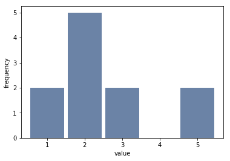

```python
import thinkplot
thinkplot.Hist(hist)
thinkplot.Config(xlabel='value', ylabel='frequency')
```

First, I'll load the data from the pregnancy file and select the records for live births.

```python
preg = nsfg.ReadFemPreg()
live = preg[preg.outcome == 1]
```

Here's the histogram of birth weights in pounds. Notice that `Hist` works with anything iterable, including a Pandas Series. The `label` attribute appears in the legend when you plot the `Hist`.

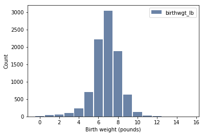

```python
hist = thinkstats2.Hist(live.birthwgt_lb, label='birthwgt_lb')
thinkplot.Hist(hist)
thinkplot.Config(xlabel='Birth weight (pounds)', ylabel='Count')
```

Before plotting the ages, I'll apply `floor` to round down:

```python
ages = np.floor(live.agepreg)
ages
```

```
0        33.0
1        39.0
2        14.0
3        17.0
4        18.0
5        27.0
6        28.0
7        30.0
8        28.0
9        32.0
10       25.0
11       23.0
12       24.0
15       28.0
16       30.0
```

[output cut: 47 more lines]

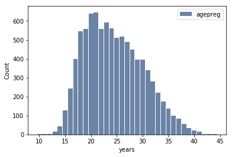

```python
hist = thinkstats2.Hist(ages, label='agepreg')
thinkplot.Hist(hist)
thinkplot.Config(xlabel='years', ylabel='Count')
```

`Hist` provides smallest, which select the lowest values and their frequencies.

```python
for weeks, freq in hist.Smallest(10):
    print(weeks, freq)
```

```
10.0 2
11.0 1
12.0 1
13.0 14
14.0 43
15.0 128
16.0 242
17.0 398
18.0 546
19.0 559
```

From live births, we can selection first babies and others using `birthord`, then compute histograms of pregnancy length for the two groups.

```python
firsts = live[live.birthord == 1]
others = live[live.birthord != 1]

first_hist = thinkstats2.Hist(firsts.prglngth, label='first')
other_hist = thinkstats2.Hist(others.prglngth, label='other')
```

```python
print(first_hist)

print(other_hist)
```

```
Hist({0: 1, 17: 1, 20: 1, 21: 1, 22: 3, 23: 1, 24: 7, 25: 1, 26: 16, 27: 1, 28: 24, 29: 9, 30: 73, 31: 15, 32: 55, 33: 28, 34: 29, 35: 159, 36: 172, 37: 208, 38: 272, 39: 2114, 40: 536, 41: 360, 42: 205, 43: 87, 44: 23, 45: 6, 46: 1, 47: 1, 48: 3})
Hist({4: 1, 9: 1, 13: 1, 17: 1, 18: 1, 19: 1, 21: 1, 22: 4, 24: 6, 25: 2, 26: 19, 27: 2, 28: 8, 29: 12, 30: 65, 31: 12, 32: 60, 33: 21, 34: 31, 35: 152, 36: 149, 37: 247, 38: 335, 39: 2579, 40: 580, 41: 227, 42: 123, 43: 61, 44: 23, 45: 4, 48: 4, 50: 2})
```

We can use `width` and `align` to plot two histograms side-by-side.

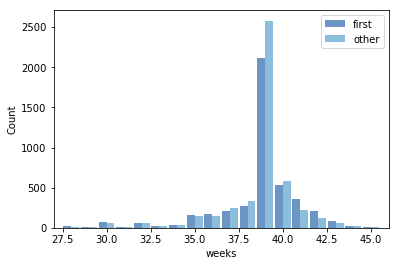

```python
width = 0.45
thinkplot.PrePlot(2)
thinkplot.Hist(first_hist, align='right', width=width)
thinkplot.Hist(other_hist, align='left', width=width)
thinkplot.Config(xlabel='weeks', ylabel='Count', xlim=[27, 46])
```

`Series` provides methods to compute summary statistics:

```python
mean = live.prglngth.mean()
var = live.prglngth.var()
std = live.prglngth.std()
```

Here are the mean and standard deviation:

```python
mean, std
```

```
(38.56055968517709, 2.702343810070593)
```

Here's are the mean pregnancy lengths for first babies and others:

```python
firsts.prglngth.mean(), others.prglngth.mean()
```

```
(38.60095173351461, 38.52291446673706)
```

And here's the difference (in weeks):

```python
firsts.prglngth.mean() - others.prglngth.mean()
```

```
0.07803726677754952
```

This functon computes the Cohen effect size, which is the difference in means expressed in number of standard deviations:

```python
def CohenEffectSize(group1, group2):
    """Computes Cohen's effect size for two groups.

    group1: Series or DataFrame
    group2: Series or DataFrame

    returns: float if the arguments are Series;
             Series if the arguments are DataFrames
    """
    diff = group1.mean() - group2.mean()

    var1 = group1.var()
    var2 = group2.var()
    n1, n2 = len(group1), len(group2)

    pooled_var = (n1 * var1 + n2 * var2) / (n1 + n2)
    d = diff / np.sqrt(pooled_var)
    return d
```

```python
CohenEffectSize(firsts.prglngth, others.prglngth)
```

```
0.028879044654449883
```

## Homework 2

*Read NSFG respondent data with .ReadFemResp() function that provided by nsfg.py and assign it a variable that called pres (This is not a question)*

- Select the `fmar1age` column that the age of respondents' at first mariage from pres,find frequencies for each age and print the values with sorted by age (tip: with value_counts() function may help) then Make a histogram of `fmar1age` the age of respondents' at first mariage. To interpret the codes see the [This website](http://www.icpsr.umich.edu/nsfg6/Controller?displayPage=labelDetails&fileCode=FEM§ion=R&subSec=7870&srtLabel=607181)  
  (2 pt)
- Find the respondents' number of mariage by `fmarno` and find frequencies for each number of mariage and print the values with sorted by number of mariage (tip: with value_counts() function may help) then Make a histogram of `fmarno` the number of mariage that done by respondents. To interpret the codes see the [This website](http://www.icpsr.umich.edu/nsfg6/Controller?displayPage=labelDetails&fileCode=FEM§ion=R&subSec=7870&srtLabel=607165)  
  (2 pt)
- Separate the respondents two group by number of mariage(use `fmarno` column) and assign them to variables that called neverMarried and married. If respondent's number of mariage is 0 assign them into neverMarried variable, If respondent's number of mariage is 1 and higher than 1 assign them into married variable. Create a histogram that shows the total income for the respondent's family(use `totincr` column) that contain these two variables in one histogram but show them with different histogram bar(column, bin) for each age these two variables must be next-by-next. (3 pt)
- Find the minumum, maximum, standard deviation, variance and mean of neverMarried and married respondents' total income and print them in a sentence for each variable. (2 pt)
- Compute the mean differences and then Cohen effect size for neverMarried and married respondents according to their total income(use `totincr` column). (3 pt)

#### Note that: There are 5 question and total of points is 12 but maximum points that can be get 10 points. Do not forget the give the name to your histogram labels(histogram's label, x-axis and y-axis label), and width of the histograms' columns must be 0.5. In addition, Your answers/codes must be uploaded to your github accounts inside a folder that called Homework2_{YourStudentNumber} then after you upload your code notify me with email that contains your github account link. The due date is the end of the next Wednesday(15.03.2017).